# Polygon Making

Alice Walsh

2022-06-24

## The goal

I want to use 2-point perspective to create a 2-D projection of 3-D cuboids as a landscape.

## Basic premise

A 3-D cube is just 7 or 9 lines. There is a center vertical line, a line on each side parallel to the center line. These are connected by four lines. Finally, depending on the location of the vanishing points, there are also two lines that define the top and bottom of the cube.

## Load packages

```r
library(dplyr)
```

```r
library(ggplot2)
library(retistruct) # to get intersection

set.seed(45)
```

## First try to do this with geom_segment

I wrote a function called `make_new_cube`. This makes a data.frame that represents the 7 or 9 lines we need to make a cube.

```r
source("functions/make_new_cube.R")

make_new_cube(xes = c(2, 4, 5), yes = c(1, 3))
```

```
##          x xend         y      yend
## 1 4.000000    4 1.0000000 3.0000000
## 2 2.000000    2 0.5000000 1.5000000
## 3 5.000000    5 0.8333333 2.5000000
## 4 4.000000    2 1.0000000 0.5000000
## 5 4.000000    5 1.0000000 0.8333333
## 6 4.000000    2 3.0000000 1.5000000
## 7 4.000000    5 3.0000000 2.5000000
## 8 2.727273    2 0.4545455 0.5000000
## 9 2.727273    5 0.4545455 0.8333333
```

We can use ggplot2 to plot this. Here I used `sample` to introduce some randomness to where the cubes are and how big they are.

All the shapes are just on top of each other. This creates an illusion of depth.

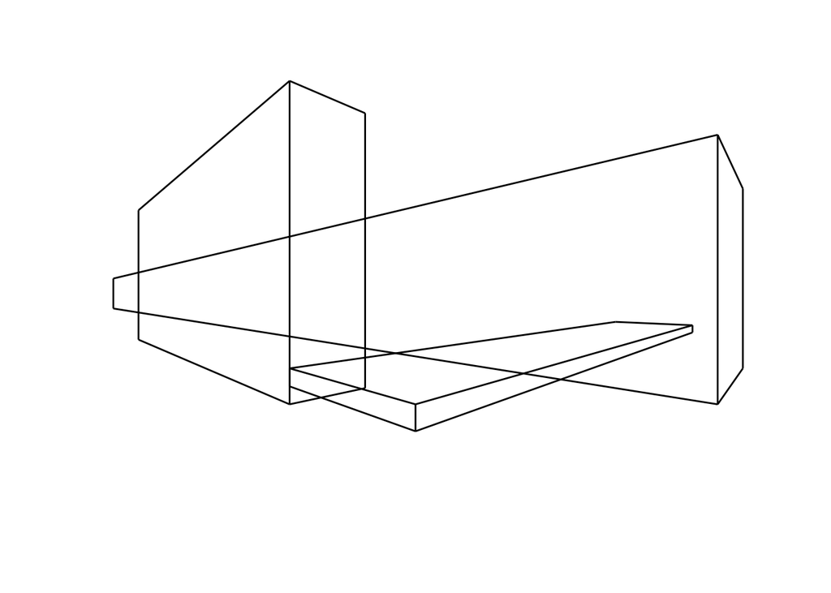

```r
# can create any n of cubes
cube <- list()
for (n in 1:3) {
  cube[[n]] <- make_new_cube(xes = sort(sample(0:29, 3)),
                             yes = sort(sample(-10:10, 2)),
                             vp_scale = 30)
}
cube <- dplyr::bind_rows(cube)

# plot
cube %>%
  ggplot() +
  geom_segment(aes(x = x, y = y, xend = xend, yend = yend)) +
  xlim(c(0,30)) +
  ylim(c(-10,10)) +
  theme_void()
```

## Switch to geom_polygon

`geom_segment` requires these aesthetics:

- x
- y
- xend
- yend

However, we want to make each “face” of the cubes filled with colors. So we need to use a different geom.

`geom_polygon` requires these aesthetics:

- x
- y

This works like `geom_path`. It “follows” the path from each point to the next and connects them based on a group aesthetic.

I created a new function to make a data.frame that feeds nicely to `geom_polygon`.

```r
source("functions/make_new_poly.R")

poly <- make_new_poly(xes = c(20,40,80),
                      yes = c(60,80),
                      horizon_y = 40)
head(poly)
```

```
##    x  y     id  value
## 1 40 60 l-side l-side
## 2 40 80 l-side l-side
## 3 20 60 l-side l-side
## 4 20 50 l-side l-side
## 5 40 60 r-side r-side
## 6 40 80 r-side r-side
```

Now I can make this into a landscape and plot. The colors are not very interesting.

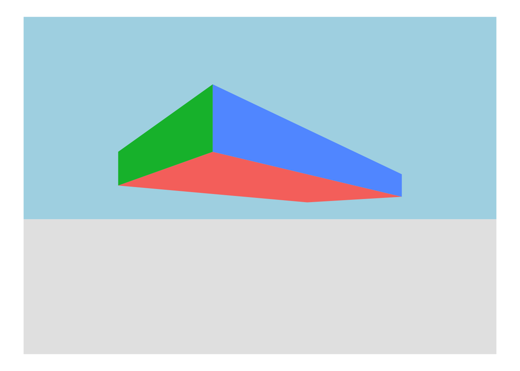

```r
# add a background poly
background_poly <- data.frame(
  x = c(0, 0, 100, 100, 0, 0, 100, 100),
  y = c(0, 40, 40, 0, 40, 100, 100, 40),
  id = c(rep("ground", 4), rep("sky", 4)),
  value = c(rep("ground", 4), rep("sky", 4)))
# plot the poly
poly %>%
  ggplot() +
  geom_polygon(alpha = 1, aes(x = x, y = y, group = id),
               fill = c(rep("gray90", 4), rep("lightblue", 4)),
               data = background_poly, inherit.aes = FALSE) +
  geom_polygon(aes(x = x, y = y, group = id, fill = value),
               alpha = 1) +
  theme_void() +
  theme(legend.position = "none")
```

## Create a wrapper to make lots of cubes

Here, I added some defaults for the colors of the faces that create an illusion of a light source where some faces are darker (further from the light source) and others are lighter (closer to the light source).

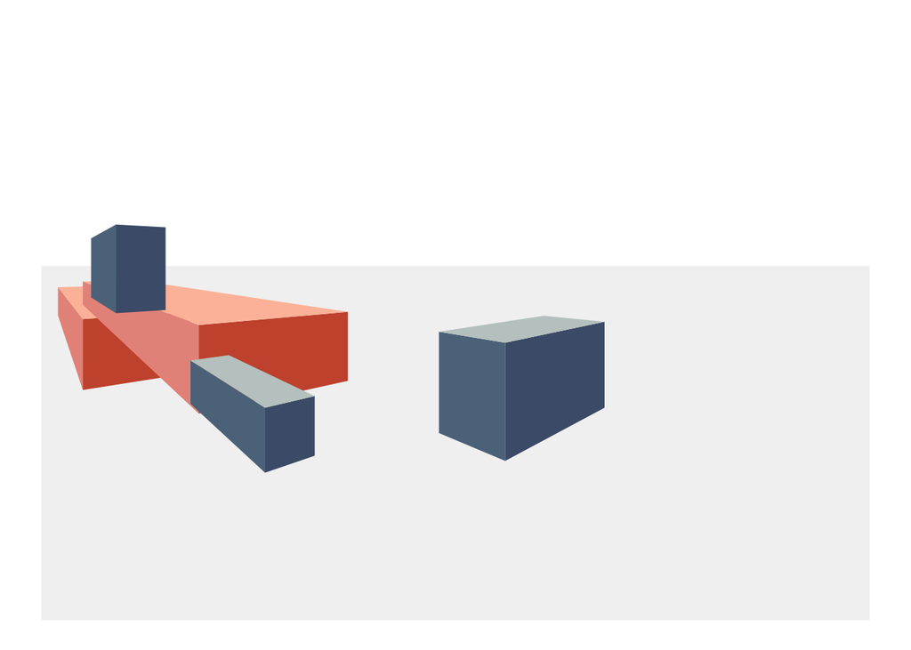

```r
source("functions/make_many_polys.R")

d <- make_many_polys(
  "examples/simple_cubes3.png", # where to write the image as png
  horizon_y = 60, # where from 0 -100 to put the horizon
  height_range = 30:40, # range of heights for cubes
  width_range = 20:50, # range of widths
  n_cubes = 5, # how many cubes to make
  n_second_color = 2) # how many to make a second color
```

```r
head(d)
```

```
##   cube_id x    y      id      value
## 1       1 5 39.0 1l-side alt-l-side
## 2       1 5 51.0 1l-side alt-l-side
## 3       1 2 56.4 1l-side alt-l-side
## 4       1 2 51.6 1l-side alt-l-side
## 5       1 5 39.0 1r-side alt-r-side
## 6       1 5 51.0 1r-side alt-r-side
```

## What about converting this to a quilting pattern?

Currently, this was all created with an arbitrary field from x = 0 to x = 100 and y = 0 to y = 100.

But I want to scale this to inches and print it out at full scale.

I also created a helper function for that.

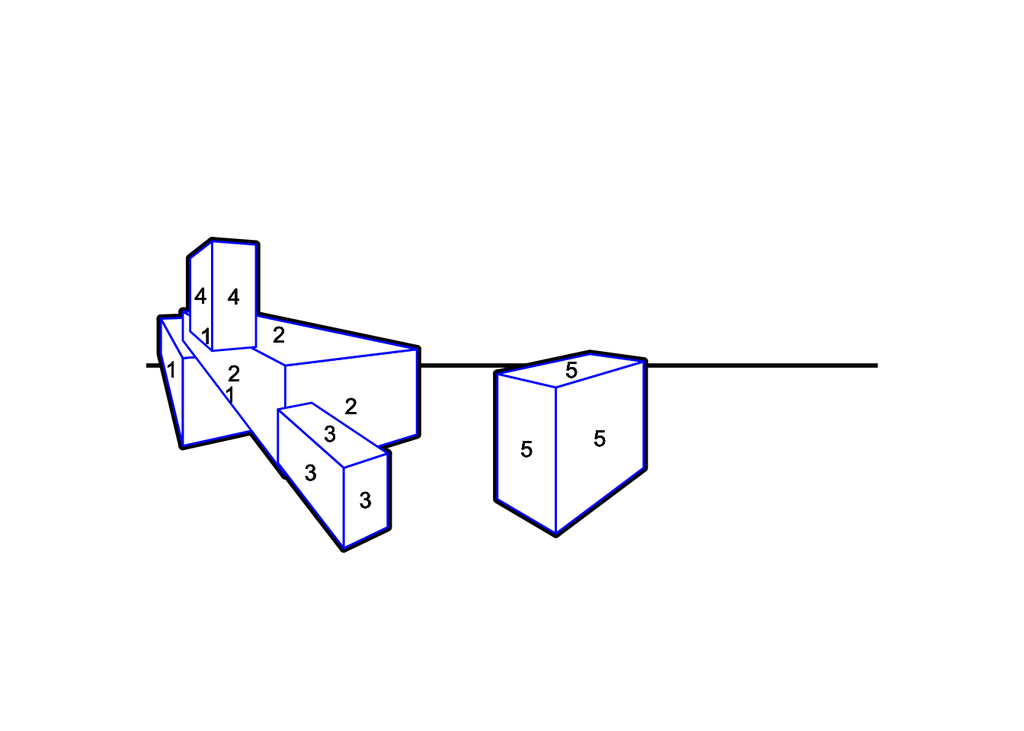

```r
source("functions/save_poly_pdf.R")

save_poly_pdf(d = d, filename = "examples/simple_cubes3.pdf")
```

You can also just save the design object, `d` for future use.

```r
saveRDS(d, "examples/simple_cubes3_data.Rds")
```

### Create individual blocks

You can print the PDF with tiling using Adobe reader.

Or create blocks by splitting the area into n x n areas and make those each their own page. Below is the code to do this, which I did not wrap into a function because there were a lot of improvements to the whole flow I wanted to make first and I was hoping to link this with the foundation paper piecing code.

However, if this will be paper pieced, then a grid of blocks may be sub-optimal as it creates additional seams with joins that could be tricky.

```r
# where should the individual block pdfs be saved?
save_location <- "~/pathtosave/"

# How big do you want this to be?
final_quilt_size <- 40 # units are arbitrary (I think in inches)
scale_factor <- final_quilt_size / 100 # my image was "100" wide
width_blocks <- final_quilt_size / 5   # I wanted 5 across, makes nice 8"

# Create a data.frame with the start and end x,y for each block
grid <- tidyr::crossing(x = seq(0, 32, width_blocks),
                        y = seq(0, 32, width_blocks)) %>%
  mutate(x_end = x + width_blocks,
         y_end = y + width_blocks) %>%
  arrange(x, y)

# Add in some information that was not in the design created previously
# This ensures that the paths are "closed" without any open edges
missing_paths <- d %>% arrange(desc(cube_id))
# create horizontal line for horizon
horizontal <- data.frame(cube_id = c("",""),
                         x = c(0, 100),
                         y = c(50, 50)) %>%
  mutate(x = x*scale_factor, y = y*scale_factor)

# run a loop over all blocks, select just that area
# save a pdf with just that area
for (i in seq_len(nrow(grid))) {
  block <- d %>%
    bind_rows(missing_paths) %>%
    arrange(cube_id) %>%
    mutate(x = x*scale_factor, y = y*scale_factor) %>%
    group_by(id) %>%
    mutate(ave_x = mean(x), ave_y = mean(y)) %>%
    ungroup() %>%
    ggplot() +
    # horizon line
    geom_path(aes(x = x, y = y, group = cube_id),
              data = horizontal,
              alpha = 1,
              color = "black",
              size = 1) +
    geom_path(aes(x = x, y = y, group = id),
              alpha = 1,
              color = "black",
              size = 2) +
    geom_polygon(aes(x = x, y = y, group = id),
                 fill = "white", color = "blue",
                 size = 0.5,
                 alpha = 1) +
    geom_text(aes(label = cube_id, x = ave_x, y = ave_y)) +
    coord_equal(clip = "off",
                xlim = c(grid$x[i], grid$x_end[i]),
                ylim = c(grid$y[i], grid$y_end[i]),
                expand = FALSE) +
    theme_void() +
    theme(legend.position = "none",
          panel.border = element_rect(colour = "black", fill=NA, size=0.5))
  ggsave(plot = block,
         filename = paste0(save_location, i, ".pdf"),
         width = width_blocks, height = width_blocks)
}
```